# 3 - Loops i condicionals

Eudald Correig

Juny 2019

En aquest document aprendrem a treballar amb loops i condicionals. No és absolutament necessari per fer estadística en R però ens pot ajudar en alguns casos.

## Què és un “loop”

Un loop és una operació en la qual el programa (en aquest cas, R) duu a terme una operació sobre **més d’un objecte** i/o de forma iterativa.

Veiem un exemple:

```r
for (i in 1:10){
  print(i)
}
```

```
## [1] 1
## [1] 2
## [1] 3
## [1] 4
## [1] 5
## [1] 6
## [1] 7
## [1] 8
## [1] 9
## [1] 10
```

En R els loops es fan amb l’operació “for”. L’operació té dues parts: 1. La *seqüència* (el que trobem entre parèntesis), on anomenem la variable muda (la i) i en predefinim els valors. El “for” iterarà sobre aquests valors.

1. El *cos* de la funció, és a dir, l’operació que volem fer, i que trobem dins dels claudàtors. En aquest cas el cos és trivial, ja que simplement imprimim en pantalla el valor de la variable muda.

Un altre exemple:

```r
suma = 0
for (i in 1:100){
  suma = suma + i
}
suma
```

```
## [1] 5050
```

Aquí estem actualitzant el valor de la variable suma cada vegada.

Inspeccionem què fa:

```r
suma = 0
for (i in 1:100){
  suma = suma + i
  print(paste0("i = ", i))
  print(paste0("suma = ", suma))
}
```

```
## [1] "i = 1"
## [1] "suma = 1"
## [1] "i = 2"
## [1] "suma = 3"
## [1] "i = 3"
## [1] "suma = 6"
## [1] "i = 4"
## [1] "suma = 10"
## [1] "i = 5"
## [1] "suma = 15"
## [1] "i = 6"
## [1] "suma = 21"
## [1] "i = 7"
## [1] "suma = 28"
## [1] "i = 8"
```

[output cut: 185 more lines]

Els valors que pren la variable muda no han de ser consecutius:

```r
primers = c(2, 3, 5, 7, 11, 13, 17, 19, 23, 29, 31, 37, 41, 43, 47, 53, 59, 61, 67, 71, 73, 79, 83, 89, 97)

suma_primers = 0
for (i in primers){
  suma_primers = suma_primers + i
}
suma_primers
```

```
## [1] 1060
```

Exemple pràctic:

```r
df = read.csv('datasets/Heart.csv')
df$X=NULL # traiem la primera, que no té cap sentit
str(df) # Mirem l'estructura de les variables
```

```
## 'data.frame':    303 obs. of  14 variables:
##  $ Age      : int  63 67 67 37 41 56 62 57 63 53 ...
##  $ Sex      : int  1 1 1 1 0 1 0 0 1 1 ...
##  $ ChestPain: Factor w/ 4 levels "asymptomatic",..: 4 1 1 2 3 3 1 1 1 1 ...
##  $ RestBP   : int  145 160 120 130 130 120 140 120 130 140 ...
##  $ Chol     : int  233 286 229 250 204 236 268 354 254 203 ...
##  $ Fbs      : int  1 0 0 0 0 0 0 0 0 1 ...
##  $ RestECG  : int  2 2 2 0 2 0 2 0 2 2 ...
##  $ MaxHR    : int  150 108 129 187 172 178 160 163 147 155 ...
##  $ ExAng    : int  0 1 1 0 0 0 0 1 0 1 ...
##  $ Oldpeak  : num  2.3 1.5 2.6 3.5 1.4 0.8 3.6 0.6 1.4 3.1 ...
##  $ Slope    : int  3 2 2 3 1 1 3 1 2 3 ...
##  $ Ca       : int  0 3 2 0 0 0 2 0 1 0 ...
##  $ Thal     : Factor w/ 3 levels "fixed","normal",..: 1 2 3 2 2 2 2 2 3 3 ...
##  $ AHD      : Factor w/ 2 levels "No","Yes": 1 2 2 1 1 1 2 1 2 2 ...
```

Veiem que les variables Sex, Fbs, RestECG, ExAng, Slope, Ca són categòriques però estan codificades com a coníntues; les podem codificar correctament una a una o totes a la vegada; això ho farem amb un loop:

```r
cat = c(2, 6, 7, 9, 11, 12)
for (i in cat){
  df[, i] = as.factor(df[, i])
}
str(df)
```

```
## 'data.frame':    303 obs. of  14 variables:
##  $ Age      : int  63 67 67 37 41 56 62 57 63 53 ...
##  $ Sex      : Factor w/ 2 levels "0","1": 2 2 2 2 1 2 1 1 2 2 ...
##  $ ChestPain: Factor w/ 4 levels "asymptomatic",..: 4 1 1 2 3 3 1 1 1 1 ...
##  $ RestBP   : int  145 160 120 130 130 120 140 120 130 140 ...
##  $ Chol     : int  233 286 229 250 204 236 268 354 254 203 ...
##  $ Fbs      : Factor w/ 2 levels "0","1": 2 1 1 1 1 1 1 1 1 2 ...
##  $ RestECG  : Factor w/ 3 levels "0","1","2": 3 3 3 1 3 1 3 1 3 3 ...
##  $ MaxHR    : int  150 108 129 187 172 178 160 163 147 155 ...
##  $ ExAng    : Factor w/ 2 levels "0","1": 1 2 2 1 1 1 1 2 1 2 ...
##  $ Oldpeak  : num  2.3 1.5 2.6 3.5 1.4 0.8 3.6 0.6 1.4 3.1 ...
##  $ Slope    : Factor w/ 3 levels "1","2","3": 3 2 2 3 1 1 3 1 2 3 ...
##  $ Ca       : Factor w/ 4 levels "0","1","2","3": 1 4 3 1 1 1 3 1 2 1 ...
##  $ Thal     : Factor w/ 3 levels "fixed","normal",..: 1 2 3 2 2 2 2 2 3 3 ...
##  $ AHD      : Factor w/ 2 levels "No","Yes": 1 2 2 1 1 1 2 1 2 2 ...
```

Amb els noms de les columnes:

```r
df = read.csv('datasets/Heart.csv')
df$X=NULL # traiem la primera, que no té cap sentit
str(df) # Mirem l'estructura de les variables
```

```
## 'data.frame':    303 obs. of  14 variables:
##  $ Age      : int  63 67 67 37 41 56 62 57 63 53 ...
##  $ Sex      : int  1 1 1 1 0 1 0 0 1 1 ...
##  $ ChestPain: Factor w/ 4 levels "asymptomatic",..: 4 1 1 2 3 3 1 1 1 1 ...
##  $ RestBP   : int  145 160 120 130 130 120 140 120 130 140 ...
##  $ Chol     : int  233 286 229 250 204 236 268 354 254 203 ...
##  $ Fbs      : int  1 0 0 0 0 0 0 0 0 1 ...
##  $ RestECG  : int  2 2 2 0 2 0 2 0 2 2 ...
##  $ MaxHR    : int  150 108 129 187 172 178 160 163 147 155 ...
##  $ ExAng    : int  0 1 1 0 0 0 0 1 0 1 ...
##  $ Oldpeak  : num  2.3 1.5 2.6 3.5 1.4 0.8 3.6 0.6 1.4 3.1 ...
##  $ Slope    : int  3 2 2 3 1 1 3 1 2 3 ...
##  $ Ca       : int  0 3 2 0 0 0 2 0 1 0 ...
##  $ Thal     : Factor w/ 3 levels "fixed","normal",..: 1 2 3 2 2 2 2 2 3 3 ...
##  $ AHD      : Factor w/ 2 levels "No","Yes": 1 2 2 1 1 1 2 1 2 2 ...
```

```r
cat = c("Sex", "Fbs", "RestECG", "ExAng", "Slope", "Ca")
for (nom in cat){
  df[, nom] = as.factor(df[, nom])
}
str(df)
```

```
## 'data.frame':    303 obs. of  14 variables:
##  $ Age      : int  63 67 67 37 41 56 62 57 63 53 ...
##  $ Sex      : Factor w/ 2 levels "0","1": 2 2 2 2 1 2 1 1 2 2 ...
##  $ ChestPain: Factor w/ 4 levels "asymptomatic",..: 4 1 1 2 3 3 1 1 1 1 ...
##  $ RestBP   : int  145 160 120 130 130 120 140 120 130 140 ...
##  $ Chol     : int  233 286 229 250 204 236 268 354 254 203 ...
##  $ Fbs      : Factor w/ 2 levels "0","1": 2 1 1 1 1 1 1 1 1 2 ...
##  $ RestECG  : Factor w/ 3 levels "0","1","2": 3 3 3 1 3 1 3 1 3 3 ...
##  $ MaxHR    : int  150 108 129 187 172 178 160 163 147 155 ...
##  $ ExAng    : Factor w/ 2 levels "0","1": 1 2 2 1 1 1 1 2 1 2 ...
##  $ Oldpeak  : num  2.3 1.5 2.6 3.5 1.4 0.8 3.6 0.6 1.4 3.1 ...
##  $ Slope    : Factor w/ 3 levels "1","2","3": 3 2 2 3 1 1 3 1 2 3 ...
##  $ Ca       : Factor w/ 4 levels "0","1","2","3": 1 4 3 1 1 1 3 1 2 1 ...
##  $ Thal     : Factor w/ 3 levels "fixed","normal",..: 1 2 3 2 2 2 2 2 3 3 ...
##  $ AHD      : Factor w/ 2 levels "No","Yes": 1 2 2 1 1 1 2 1 2 2 ...
```

# Condicions en R

## Símbols de comparació

Els possibles símbols de comparació són:

```r
Símbol = c("<", "<=", ">", ">=", "==", "!=", "!x", "x | y", "x & y", "%in%")
Explicació = c("Més petit", "Més petit o igual", "Més gran", "Més gran o iqual", "Exactament igual",
                 "Diferent", "No és x", "o x o y", "x i y", "dins de")
kable(cbind(Símbol, Explicació))
```

| Símbol | Explicació |
| --- | --- |
| < | Més petit |
| <= | Més petit o igual |
| > | Més gran |
| >= | Més gran o iqual |
| == | Exactament igual |
| != | Diferent |
| !x | No és x |
| x \| y | o x o y |
| x & y | x i y |
| %in% | dins de |

Exemples:

```r
a = 2
b = 3
d = c(2, 4)

a == b
```

```
## [1] FALSE
```

```r
a != b
```

```
## [1] TRUE
```

```r
a < b
```

```
## [1] TRUE
```

```r
a %in% d
```

```
## [1] TRUE
```

```r
b %in% d
```

```
## [1] FALSE
```

Agrupats:

```r
(a == b | a %in% d)
```

```
## [1] TRUE
```

```r
(a == b & a %in% d)
```

```
## [1] FALSE
```

Negacions:

```r
!TRUE
```

```
## [1] FALSE
```

```r
# per exemple, tots els que no estiguin a una llista:
!b %in% d
```

```
## [1] TRUE
```

Els condicionals evaluen una condició i actuen en cas que aquesta es compleixi.

Per exemple:

```r
a = 10

if (a > 5){
  print(a)
}
```

```
## [1] 10
```

Els condicionals amb R (i en la majoria de llenguatges) es fan amb “if”, i l’estructura és semblant a la dels loops. En aquest as, el que hi ha dins del parèntesis és una condició i, entre els claudàtors, l’acció.

Podem fer condicionals amb més d’una condició:

```r
a = -1
if (a > 5 | a < 0){
  print(a)
}
```

```
## [1] -1
```

Podem evaluar diferents condicions amb l’expressió “else if” i “else”:

```r
if (a > 0){

  print("La a és positiva.")

} else if (a < 0){

  print("La a és negativa.")

} else if (a == 0){

  print("La a és 0.")

} else{

  print("La a no és un número.")

}
```

```
## [1] "La a és negativa."
```

## Funció which

Per saber quins compleixen una condició:

```r
a = round(rnorm(100, 50, 10))

which(a > 65)
```

```
## [1]  1 14 35 74 85
```

# Loops amb condicionals

Podem ajuntar les dues operacions de la següent manera:

```r
suma_parells = 0
suma_senars = 0
for (i in 1:100){
  if (i %% 2 == 0){
    suma_parells = suma_parells + i
  }
  else {
    suma_senars = suma_senars + i
  }
}
suma_parells
```

```
## [1] 2550
```

```r
suma_senars
```

```
## [1] 2500
```

## ifelse

R té una funció molt útil que ens permet fer aquest tipus d’operacions de forma més simple i ràpida (ja que és una operació vectoritzada) amb la funció ifelse:

```r
dades = read.csv('datasets/dades.csv')
dades$persona_gran = ifelse(dades$edat>75, "sí", "no")
```

Exemple pràctic:

Importem una base de dades amb moltes comparacions múltiples:

```r
df = read.csv('datasets/dades_mult.csv')
```

```r
nivell_sig = 0.01
for (i in 2:ncol(df)){
  wt = wilcox.test(df[,i]~df$Grup)
  p_val = wt$p.value

  if (p_val < nivell_sig){
    print(paste0("La variable ", names(df)[i], " és significativa amb p-valor ", p_val, "."))
  }
}
```

```
## [1] "La variable X1 és significativa amb p-valor 4.01600651345356e-06."
## [1] "La variable X4 és significativa amb p-valor 0.000391379883002727."
## [1] "La variable X5 és significativa amb p-valor 0.00014238041348304."
## [1] "La variable X10 és significativa amb p-valor 0.000369744778919733."
## [1] "La variable X17 és significativa amb p-valor 9.69392760263038e-05."
## [1] "La variable X21 és significativa amb p-valor 8.4997238613107e-05."
## [1] "La variable X22 és significativa amb p-valor 7.5265358661855e-05."
## [1] "La variable X23 és significativa amb p-valor 0.000528167813415191."
## [1] "La variable X28 és significativa amb p-valor 0.00474393250855644."
## [1] "La variable X30 és significativa amb p-valor 0.00397035539861884."
## [1] "La variable X33 és significativa amb p-valor 0.000123211579974947."
## [1] "La variable X34 és significativa amb p-valor 0.00657485925563053."
## [1] "La variable X39 és significativa amb p-valor 0.00330394890604424."
```

Podem fer coses més complicades:

```
## [1] "El resultat per la variable X1 és:"
```

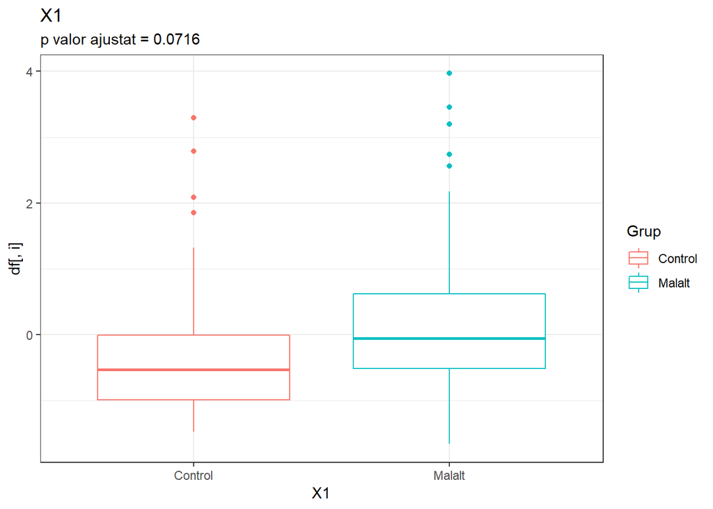

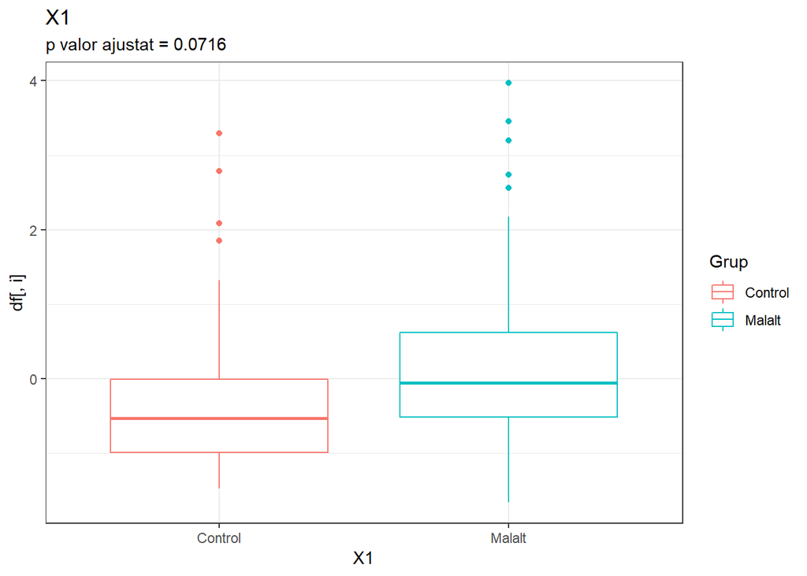

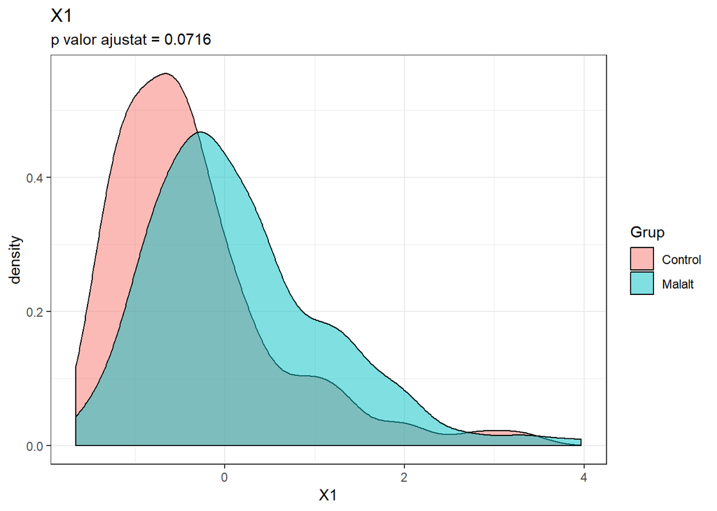

```
## [1] "El resultat per la variable X4 és:"
```

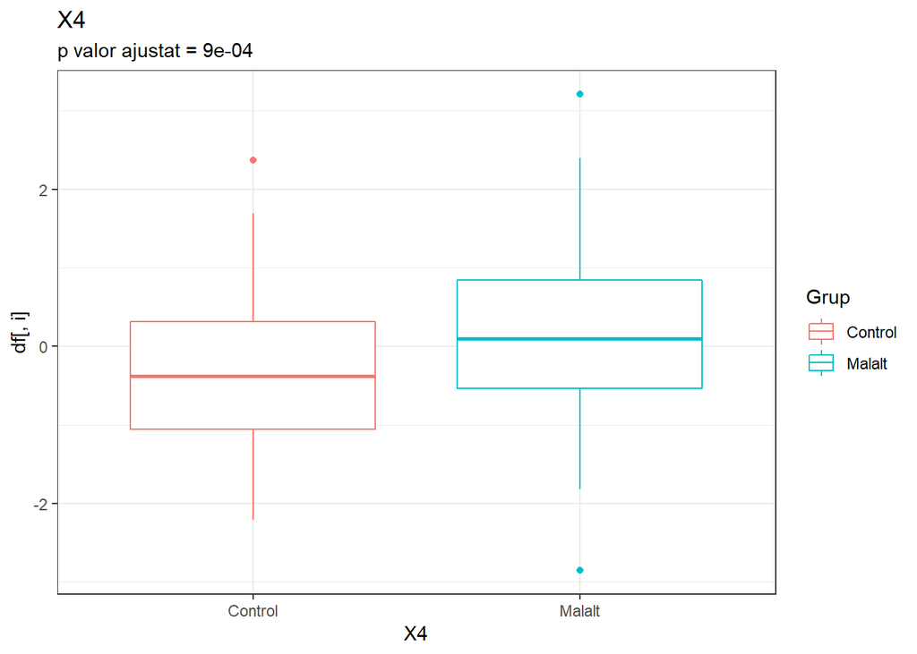

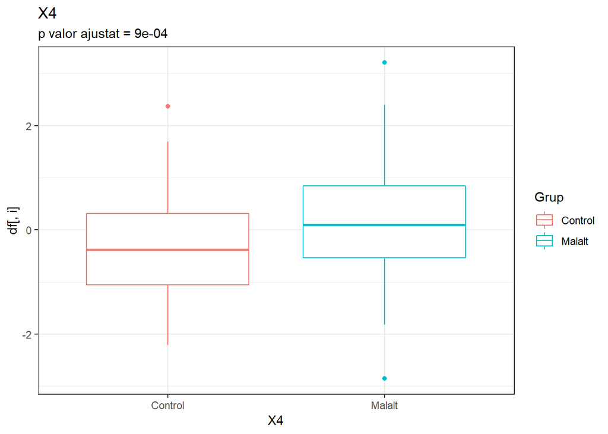

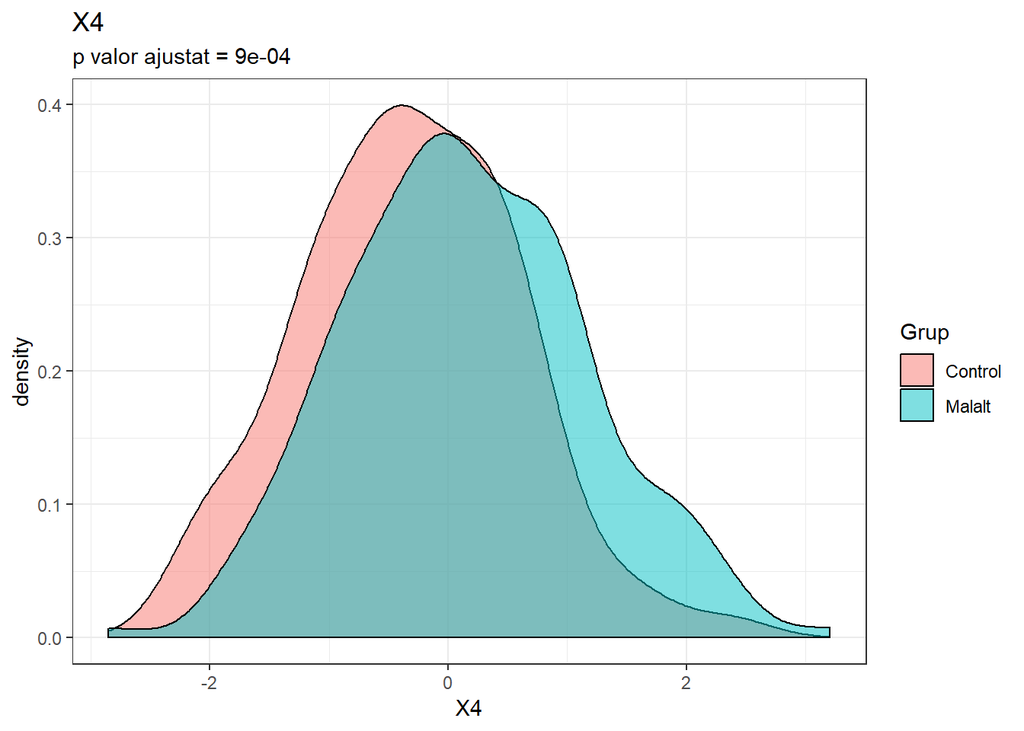

```
## [1] "El resultat per la variable X5 és:"
```

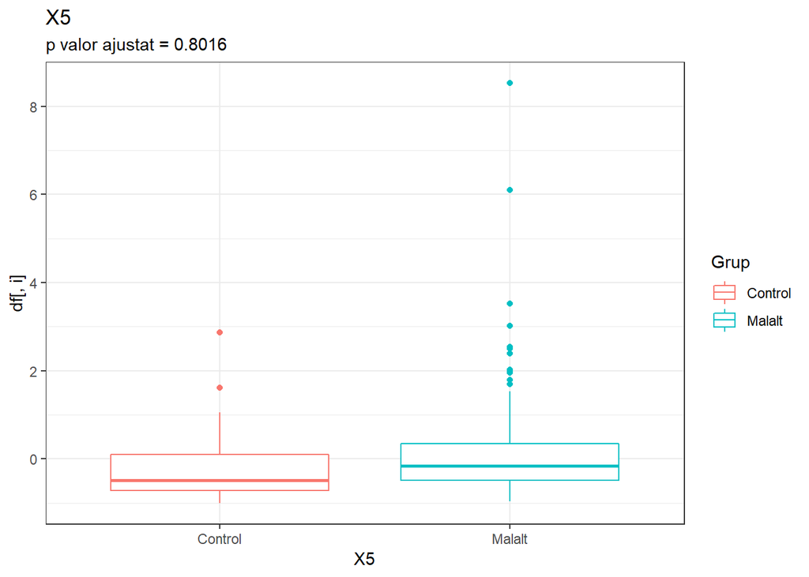

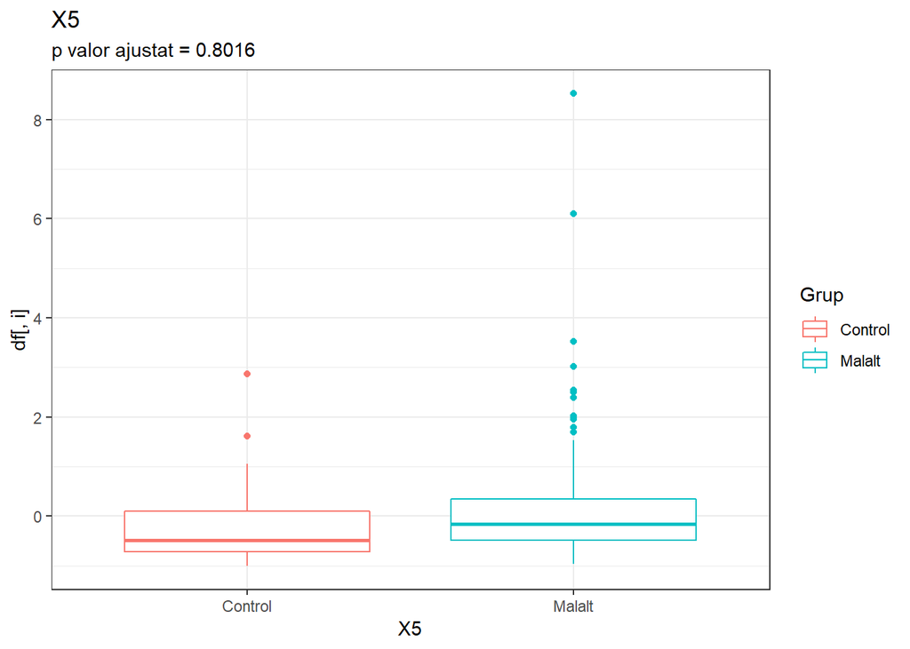

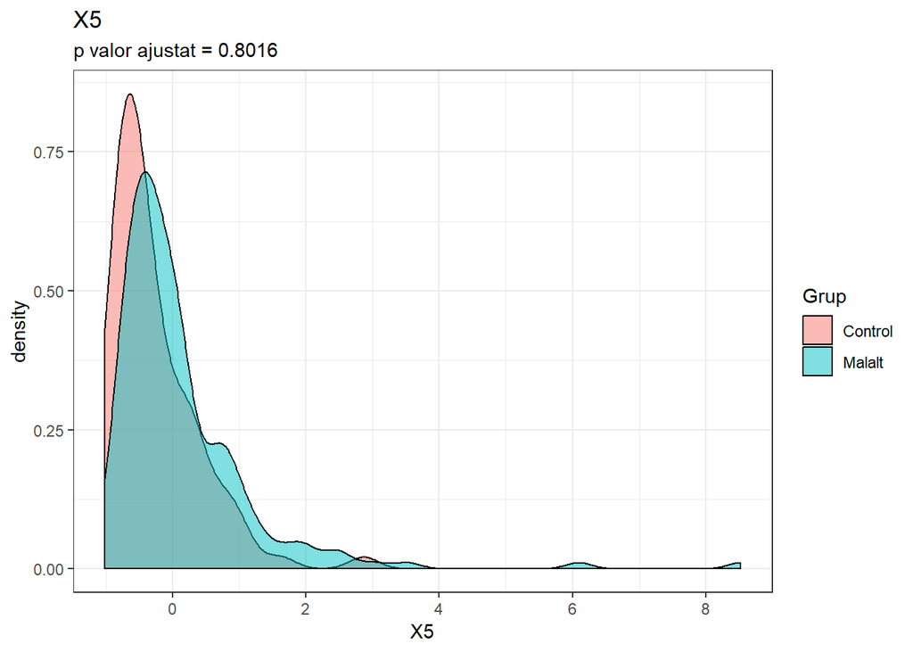

```
## [1] "El resultat per la variable X10 és:"
```

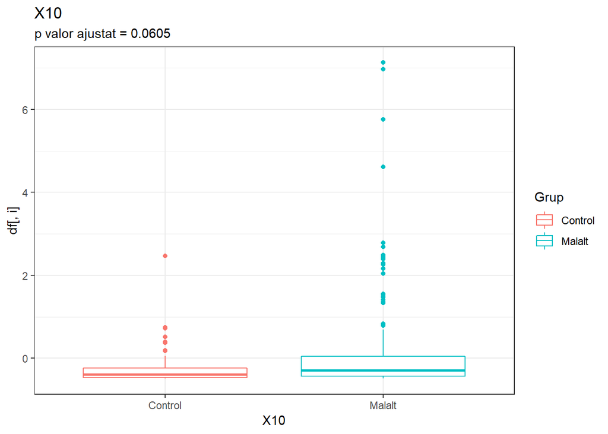

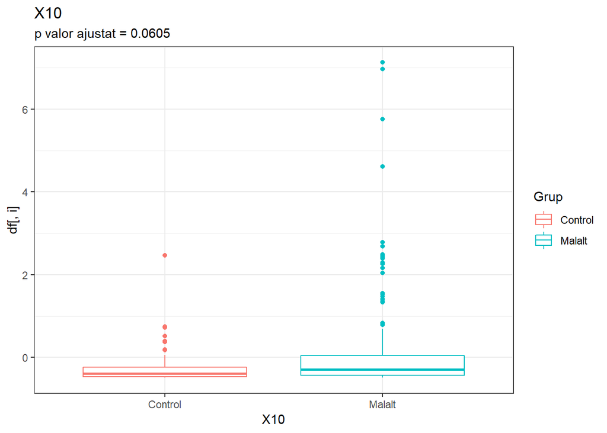

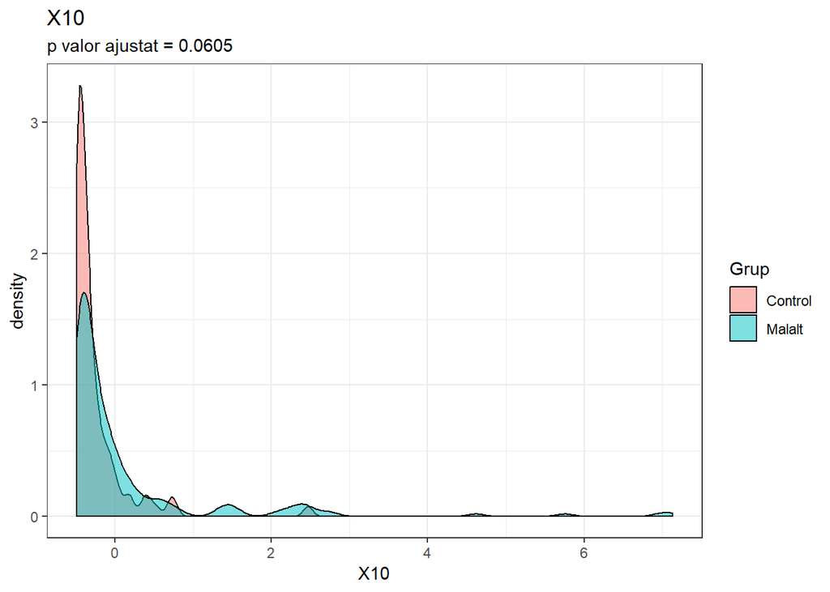

```
## [1] "El resultat per la variable X17 és:"
```

[15 more figures not shown]

```r
  pvals = c()

    for (i in 2:(ncol(df))){
      test = wilcox.test(df[, i] ~ df$Grup)
      pvals = c(pvals, test$p.value)
    }

  p_adj = p.adjust(pvals, "BH") # Ajuntem per Benjamin Hochberg
  quines = which(p_adj<nivell_sig)
  quines = quines + 1 # Ajustem perquè la primera és el grup.

  for (i in quines){
    p1 = ggplot(df, aes(x = Grup, y = df[, i], colour = Grup)) +
      geom_boxplot() +
      labs(title = colnames(df)[i],
           subtitle = paste0("p valor ajustat = ", round(p_adj[i], 4))) +
      xlab(colnames(df)[i]) +
      theme_bw()

    p2 = ggplot(df, aes(x = Grup, y = df[, i], colour = Grup)) +
      geom_boxplot() +
      labs(title = colnames(df)[i],
           subtitle = paste0("p valor ajustat = ", round(p_adj[i], 4))) +
      xlab(colnames(df)[i]) +
      theme_bw()

    p3 = ggplot(df, aes(x = df[, i], fill = Grup)) +
      geom_density(alpha = .5)+
      labs(title = colnames(df)[i],
           subtitle = paste0("p valor ajustat = ", round(p_adj[i], 4))) +
      xlab(colnames(df)[i]) +
      theme_bw()

    print(paste0("El resultat per la variable ", names(df)[i], " és:"))
    print(p1)
    print(p2)
    print(p3)
    }
```